# logistic_regression

joseferson da silva barreto

2022-11-25

# Introdução

Pesquisas indicam que a insuficiencia renal afeta cerca de 65 milhões de pessoas no mundo,, ela é dividida em 2 tipos : insuficiência cardiáca com fração de ejeção reduzida e insuficiência cardiaca com fração de ejeção preservada.

# Carregando o Banco de Dados

```r
library(tidyverse)
dados<-read.csv("heart_failure_clinical_records_dataset.csv",sep = ",")
```

### Análise exploratória e tratamento dos dados

Toda boa análise deve ser iniciada pela análise exploratória dos dados,vamos começar verificando se temos a presença de dados faltantes utilizando o comando abaixo

```r
round(mean(is.na(dados))*100,10)
```

```
## [1] 0
```

como podemos obervar não temos a presença de nemhum dado faltante ,vamos verificar os tipos das nossas variáveis

```r
glimpse(dados)
```

```
## Rows: 299
## Columns: 13
## $ age                      <dbl> 75, 55, 65, 50, 65, 90, 75, 60, 65, 80, 75, 6…
## $ anaemia                  <int> 0, 0, 0, 1, 1, 1, 1, 1, 0, 1, 1, 0, 1, 1, 1, …
## $ creatinine_phosphokinase <int> 582, 7861, 146, 111, 160, 47, 246, 315, 157, …
## $ diabetes                 <int> 0, 0, 0, 0, 1, 0, 0, 1, 0, 0, 0, 0, 0, 0, 0, …
## $ ejection_fraction        <int> 20, 38, 20, 20, 20, 40, 15, 60, 65, 35, 38, 2…
## $ high_blood_pressure      <int> 1, 0, 0, 0, 0, 1, 0, 0, 0, 1, 1, 1, 0, 1, 1, …
## $ platelets                <dbl> 265000, 263358, 162000, 210000, 327000, 20400…
## $ serum_creatinine         <dbl> 1.90, 1.10, 1.30, 1.90, 2.70, 2.10, 1.20, 1.1…
## $ serum_sodium             <int> 130, 136, 129, 137, 116, 132, 137, 131, 138, …
## $ sex                      <int> 1, 1, 1, 1, 0, 1, 1, 1, 0, 1, 1, 1, 1, 1, 0, …
## $ smoking                  <int> 0, 0, 1, 0, 0, 1, 0, 1, 0, 1, 1, 1, 0, 0, 0, …
## $ time                     <int> 4, 6, 7, 7, 8, 8, 10, 10, 10, 10, 10, 10, 11,…
## $ DEATH_EVENT              <int> 1, 1, 1, 1, 1, 1, 1, 1, 1, 1, 1, 1, 1, 1, 0, …
```

como podemos observar algumas classes estão como sendo inteiros ,ou seja,valores numericos ,vamos converte-las para fator

```r
dados1<-dados|>   select(anaemia,diabetes,high_blood_pressure,sex,smoking,DEATH_EVENT
                 ) |>
mutate_if(is.integer,as.factor)

dados2<-dados|>   select(age,creatinine_phosphokinase,ejection_fraction,platelets,serum_creatinine,serum_sodium,time
                 )


dados<-cbind(dados2,dados1)

table(dados$DEATH_EVENT)
```

```
##
##   0   1
## 203  96
```

```r
203/299
```

```
## [1] 0.6789298
```

agora vamos salvar o nosso nosso banco de dados

```r
write.csv(dados,"dados_edit.csv",row.names = F,sep = ";")
```

## Balanciamento dos dados

Como nossos dados não estão com uma proporção equivalente em nossa variável target então vamos reaalizar o balanciamento dos nossos dados ,para isso vamos utilizar os comandos abaixo

```r
Base_1 = dados %>% filter( DEATH_EVENT == 1 )
Base_0 =dados   %>% filter( DEATH_EVENT == 0  )


Base_0_balan = Base_0[ sample(x=1:dim(Base_0)[1], size = dim(Base_1)[1], replace = F ),   ]
banco_balanced <- rbind(Base_1, Base_0_balan)

#prop.table( table(banco_balanced$DEATH_EVENT  ) )


write.csv(banco_balanced,"dados1_edit.csv",row.names = F,sep = ";")
```

## Análise Exploratória

Finalmente após a primeira etapa de preparação dos dados vamos iniciar a análise exploratória de forma prática utilizando a linguagem python , para isso vamos utilizar os seguintes comandos

```python
import pandas as pd

import numpy as np
import sweetviz as sv
import warnings


warnings.filterwarnings("ignore")


dados=pd.read_csv("dados1_edit.csv")

my_report = sv.analyze(dados) # cria o reporte e chama de my_report
```

[output not shown]

```python
#my_report.show_html()
```

```python
msk = np.random.rand(len(dados)) < 0.7
train = dados[msk]
test = dados[~msk]

#train.head() # 80%
```

```python
my_report = sv.compare([train, 'training set'], [test, 'testing set'])

#my_report.show_html()
```

[output not shown]

```python
#dados1=dados[0:11]
my_report = sv.compare_intra(dados, dados['DEATH_EVENT']==1,['morreu','não morreu'])
#my_report.show_html()
```

[output not shown]

# Voltando para o R

Após a análise exploratória vamos voltar a utlizar a limguagem R,vamos observar as distribuições de nossas variaveis númericas

```r
#dados ja balanceado
dados<- read.csv("dados1_edit.csv",sep = ",")




dados$age<-round(dados$age,0)
# qplot(dados$age,
#         main = "Histogram energy",
#         xlab = "valores",
#         ylab = "frequencias",
#         fill=I("orange"),
#         col=I("black")  ,
#           col="red",
#         fill="green",
#         alpha= .9) +
#      geom_density(alpha = 0.5)+
  library(plotly)
  ff<-ggplot(dados, aes(x = dados$age)) +

  geom_histogram(aes(y = ..density..),
                 binwidth = 1,     # Amplitude da classe
                 fill = 'dodgerblue',
                 color = 'black')+ # Linha de densidade

  stat_function(fun = dnorm, color='red', size = 2,
                args = list(mean = mean(dados$age),
                            sd = sd(dados$age)))+

  theme_light()
```

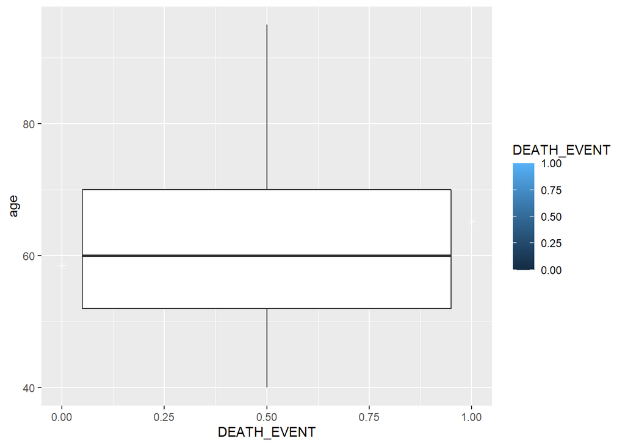

```r
ggplot(dados, aes(x = DEATH_EVENT, y = age, fill = DEATH_EVENT)) +
  geom_boxplot() +
  stat_summary(fun = "mean", geom = "point", shape = 8,
               size = 2, color = "white")
```

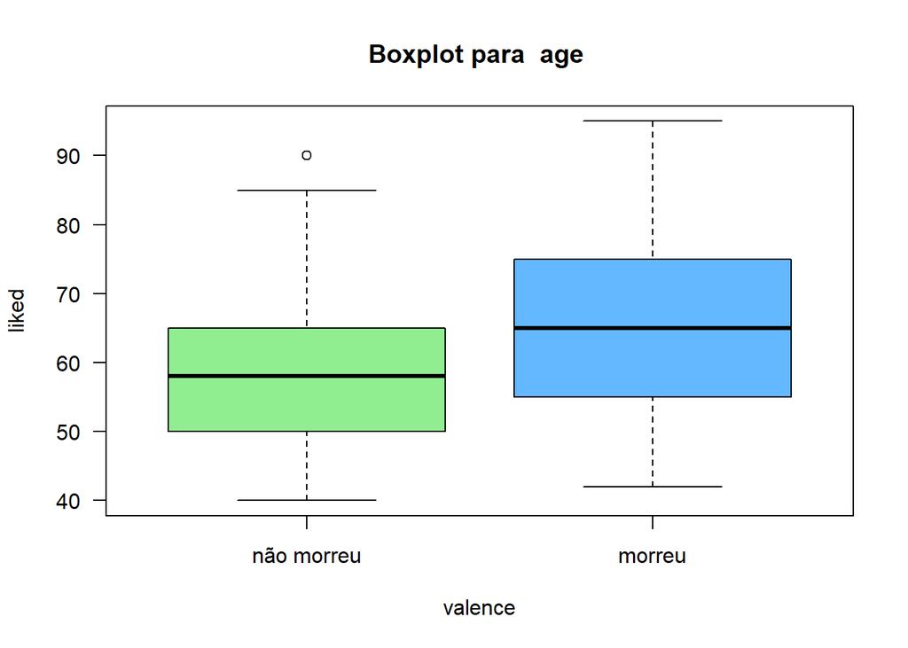

```r
boxplot (dados$age~dados$DEATH_EVENT,
        main = "Boxplot para  age ",
        xlab = "valence",
        ylab = "liked",
        las = 1,
        col = c ("light green", "steelblue1"),
        names = c("não morreu", "morreu")
        )
```

```r
# ggplot(ds, aes(x = label, y = temperature, fill = label)) +
#   geom_boxplot() +
#   stat_summary(fun = "mean", geom = "point", shape = 8,
#                size = 2, color = "white")
```

```r
dados$diferenaliked<-dados$DEATH_EVENT-dados$age
shapiro.test(dados$diferenaliked)
```

```
##
##  Shapiro-Wilk normality test
##
## data:  dados$diferenaliked
## W = 0.97434, p-value = 0.001348
```

```r
0.001793 > 0.05
```

```
## [1] FALSE
```

Logo, podemos afirma que não há evidências que a variável **age** siga distribuição normal, ou seja ,vamos utilizar o teste Mann-Whitney para verificar asociação entre nossa variável resposta com **age**

```r
wilcox.test(dados$age~dados$DEATH_EVENT, data=dados,correct=T)
```

```
##
##  Wilcoxon rank sum test with continuity correction
##
## data:  dados$age by dados$DEATH_EVENT
## W = 3307.5, p-value = 0.000715
## alternative hypothesis: true location shift is not equal to 0
```

Como o Pvalor < 0,05, rejeitamos a hipótese nula em favor da hipótese alternativa ,logo , a médiana da diferênça dos valores é realmente diferente de zero , nesse caso, podemos afirmar que existe associação significativa entre as variáveis .

### creatinine_phosphokinase

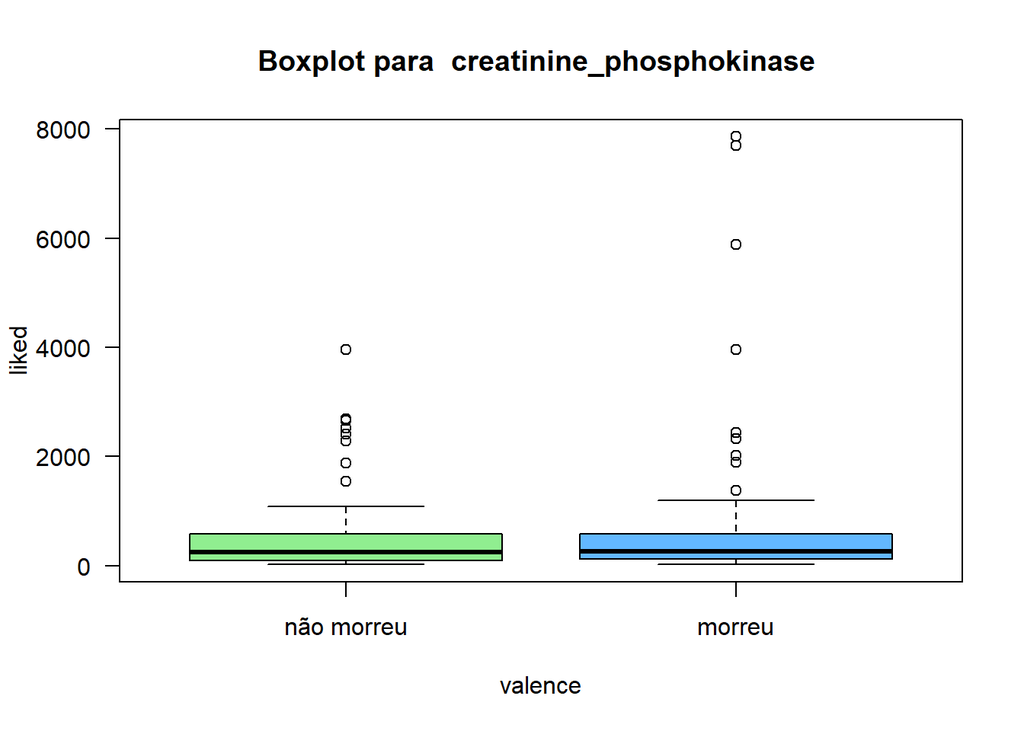

```r
boxplot (dados$creatinine_phosphokinase~dados$DEATH_EVENT,
        main = "Boxplot para  creatinine_phosphokinase ",
        xlab = "valence",
        ylab = "liked",
        las = 1,
        col = c ("light green", "steelblue1"),
        names = c("não morreu", "morreu")
        )
```

É possível verificar que temos a presença de outliers nessa variável

```r
# ggplot(dados, aes(x = dados$creatinine_phosphokinase)) +
#
#   geom_histogram(aes(y = ..density..),
#                  binwidth = 1,     # Amplitude da classe
#                  fill = 'dodgerblue',
#                  color = 'black')+ # Linha de densidade
#
#   stat_function(fun = dnorm, color='red', size = 2,
#                 args = list(mean = mean(dados$creatinine_phosphokinase),
#                             sd = sd(dados$creatinine_phosphokinase)))+
#
#   theme_light()

wilcox.test(dados$creatinine_phosphokinase~dados$DEATH_EVENT, data=dados,correct=T)
```

```
##
##  Wilcoxon rank sum test with continuity correction
##
## data:  dados$creatinine_phosphokinase by dados$DEATH_EVENT
## W = 4442.5, p-value = 0.6675
## alternative hypothesis: true location shift is not equal to 0
```

### ejection_fraction

[figure not shown]

```r
boxplot (dados$ejection_fraction~dados$DEATH_EVENT,
        main = "Boxplot para  creatinine_phosphokinase ",
        xlab = "valence",
        ylab = "DEATH_EVENT",
        las = 1,
        col = c ("light green", "steelblue1"),
        names = c("não morreu", "morreu")
        )
```

Podemos perceber a presença de outliers, vamos verificar se a variável segue distribuição normal

```r
options(scipen=999)
diferenaliked<-dados$DEATH_EVENT-dados$ejection_fraction
shapiro.test(diferenaliked)
```

```
##
##  Shapiro-Wilk normality test
##
## data:  diferenaliked
## W = 0.95335, p-value = 0.000006119
```

```r
wilcox.test(dados$ejection_fraction~dados$DEATH_EVENT, data=dados,correct=T)
```

```
##
##  Wilcoxon rank sum test with continuity correction
##
## data:  dados$ejection_fraction by dados$DEATH_EVENT
## W = 6441, p-value = 0.000001674
## alternative hypothesis: true location shift is not equal to 0
```

fazendo o mesmo processo para as demais

```r
#install.packages("gtsummary")
library(gtsummary)


wilcox.test(dados$platelets~dados$DEATH_EVENT, data=dados,correct=T)
```

```
##
##  Wilcoxon rank sum test with continuity correction
##
## data:  dados$platelets by dados$DEATH_EVENT
## W = 4759.5, p-value = 0.6948
## alternative hypothesis: true location shift is not equal to 0
```

```r
wilcox.test(dados$serum_creatinine~dados$DEATH_EVENT, data=dados,correct=T)
```

```
##
##  Wilcoxon rank sum test with continuity correction
##
## data:  dados$serum_creatinine by dados$DEATH_EVENT
## W = 2651.5, p-value = 0.0000003361
## alternative hypothesis: true location shift is not equal to 0
```

```r
wilcox.test(dados$serum_sodium~dados$DEATH_EVENT, data=dados,correct=T)
```

```
##
##  Wilcoxon rank sum test with continuity correction
##
## data:  dados$serum_sodium by dados$DEATH_EVENT
## W = 5777, p-value = 0.002325
## alternative hypothesis: true location shift is not equal to 0
```

```r
wilcox.test(dados$time~dados$DEATH_EVENT, data=dados,correct=T)
```

```
##
##  Wilcoxon rank sum test with continuity correction
##
## data:  dados$time by dados$DEATH_EVENT
## W = 7766, p-value = 0.0000000000000002362
## alternative hypothesis: true location shift is not equal to 0
```

```r
variaveis<-c("platelets","serum_creatinine","serum_sodium","time")
valor_test_W<-c("0.6833","0.00000005241","0.0008524","0.000000000000002719")

data.frame(cbind(variaveis,valor_test_W))
```

[output not shown]

## Teste Qui-Quadrado para as variáveis resposta

O teste Qui-quadrado é um teste não-paramétrico utilizado, basicamente, para três finalidades específicas, que são:

Verificar as distribuições de probabilidades de cada categoria de uma variável em relação a um valor teórico esperado (aderência),

Verificar se as distribuições das categorias são as mesmas para diferentes subpopulações de interesse (homogeneidade)

Verificar se duas variáveis categóricas são independentes (independência).

Apesar das diferenças em relação às perguntas de pesquisa, o sistema matemático é o mesmo.